# HTP Report

Damon Leach, Kelly Stratton, Lisa Bramer

2023-02-24

## Software Used

R 4.2.1 (R Core Team 2018) was used for all computations. The following packages were used:

| Package | Use | Reference |
| --- | --- | --- |
| dplyr | General data processing | Wickham et al. (2018) |
| ggplot2 | Creating figures | Wickham (2016) |
| pmartR | Processing/normalizing/analyzing protein data | Degnan et al. (2023) |

As the data is unlabeled, there is no need to undergo isobaric normalization. Prior to any other normalization or filtering, there were 294,655 peptides in the data and 187,089 unique peptides. There were also 2,357,240 missing observations accounting for 88.89% missingness.

## Normalization

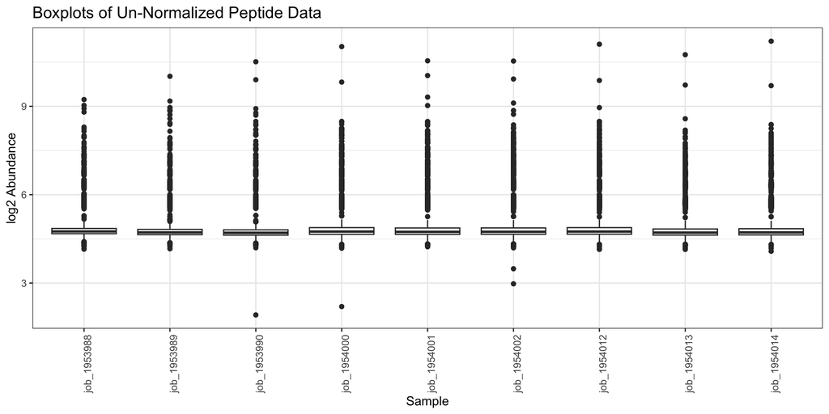

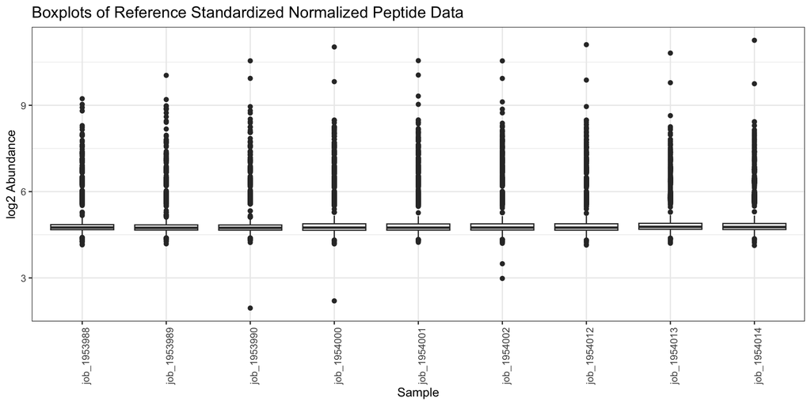

**Figure 1: Peptide-level data before (left) and after (right) undergoing normalization**

## Protein Quantitation

Protein quantitation on the data using the “rollup” method placing the data on the protein-level rather than peptide-level. After undergoing protein quantitation, there were 16,796 unique proteins in the data. There were 113,472 missing observations accounting for 75.07% missingness.

## Reverse Hits/Contaminants

We then remove reverse hits and contaminants that may still be present in the dataset.

Reverse hits and contaminants that remained in the data were removed. After removing those molecules, there were 8,998 unique proteins in the data. There were 57,130 missing observations accounting for 70.55% missingness. **Figure 2** shows the normalized protein-level data after quantitation and removal of reverse hits and contaminants.

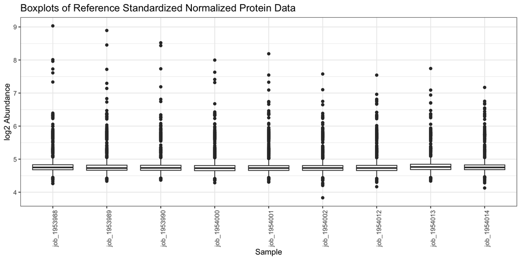

**Figure 2: Protein-level data after undergoing quantitation and removal of reverse hits and contaminants**

## Results

We can look at the number of significant fold changes between all comparisons. **Figure 3** demonstrates the number of significant fold changes by each pairwise comparison in both a bar plot and a volcano plot.

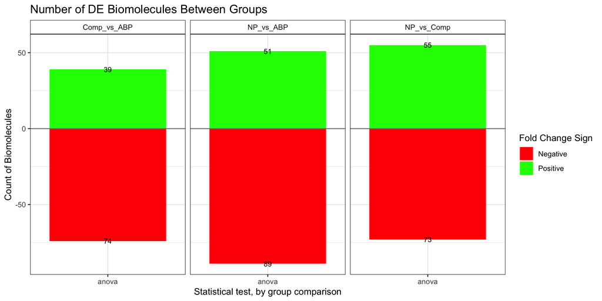

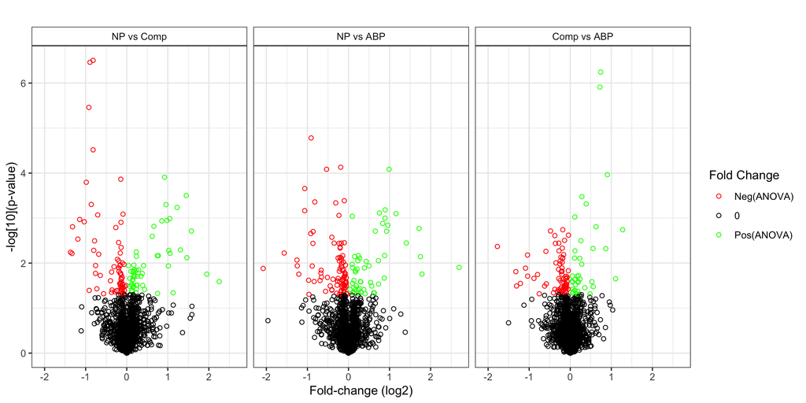

**Figure 3: Significant fold changes by both bar plot (left) and volcano plot (right)**

Statistical results for each protein are given in the file ‘results_unlabeled.csv’ . Within this csv, there are the following columns:

| Column Name | Description |
| --- | --- |
| Protein | Protein identifier |
| Count_X | Number of counts for Group X |
| Mean_X | Mean value for Group X |
| Fold_change_X_vs_Y. | log2 fold-change of viral strain X/Y |
| P_value_A_X_vs_Y | Adjusted p-value for comparison of X and Y |
| Flag_A_X_vs_Y | Flag for comparison of X and Y condition |
| Protein_Collection_ID | Protein collection ID |
| Protein_Collection | Protein collection |
| Description | Description |
| Reference_ID | Reference ID |
| Residue_Count | Residue count |
| Monotopic_Mass | Monotopic mass |
| Protein_ID | Protein ID |

## References

Degnan, David J, Kelly G Stratton, Rachel Richardson, Daniel Claborne, Evan A Martin, Nathan A Johnson, Damon Leach, Bobbie-Jo M Webb-Robertson, and Lisa M Bramer. 2023. “pmartR 2.0: A Quality Control, Visualization, and Statistics Pipeline for Multiple Omics Datatypes.” *Journal of Proteome Research* 22 (2): 570–76. https://doi.org/10.1021/acs.jproteome.2c00610.

R Core Team. 2018. *R: A Language and Environment for Statistical Computing*. Vienna, Austria: R Foundation for Statistical Computing. https://www.R-project.org/.

Wickham, Hadley. 2016. *Ggplot2: Elegant Graphics for Data Analysis*. Springer-Verlag New York. http://ggplot2.org.

Wickham, Hadley, Romain François, Lionel Henry, and Kirill Müller. 2018. *Dplyr: A Grammar of Data Manipulation*. https://CRAN.R-project.org/package=dplyr.